# BA 64060 - Assignment 1

Ana Sarmiento

2026-09-10

### Step 1 & 2: Download a dataset and import the Data

I imported the Customer Personality Analysis dataset from Kaggle.

```r
# Source: Kaggle "Customer Personality Analysis" dataset by imakash3011
# https://www.kaggle.com/datasets/imakash3011/customer-personality-analysis

marketing <- read.csv("marketing_campaign.csv", sep = "\t")
str(marketing)
```

```
## 'data.frame':    2240 obs. of  29 variables:
##  $ ID                 : int  5524 2174 4141 6182 5324 7446 965 6177 4855 5899 ...
##  $ Year_Birth         : int  1957 1954 1965 1984 1981 1967 1971 1985 1974 1950 ...
##  $ Education          : chr  "Graduation" "Graduation" "Graduation" "Graduation" ...
##  $ Marital_Status     : chr  "Single" "Single" "Together" "Together" ...
##  $ Income             : int  58138 46344 71613 26646 58293 62513 55635 33454 30351 5648 ...
##  $ Kidhome            : int  0 1 0 1 1 0 0 1 1 1 ...
##  $ Teenhome           : int  0 1 0 0 0 1 1 0 0 1 ...
##  $ Dt_Customer        : chr  "04-09-2012" "08-03-2014" "21-08-2013" "10-02-2014" ...
##  $ Recency            : int  58 38 26 26 94 16 34 32 19 68 ...
##  $ MntWines           : int  635 11 426 11 173 520 235 76 14 28 ...
##  $ MntFruits          : int  88 1 49 4 43 42 65 10 0 0 ...
##  $ MntMeatProducts    : int  546 6 127 20 118 98 164 56 24 6 ...
##  $ MntFishProducts    : int  172 2 111 10 46 0 50 3 3 1 ...
##  $ MntSweetProducts   : int  88 1 21 3 27 42 49 1 3 1 ...
##  $ MntGoldProds       : int  88 6 42 5 15 14 27 23 2 13 ...
##  $ NumDealsPurchases  : int  3 2 1 2 5 2 4 2 1 1 ...
##  $ NumWebPurchases    : int  8 1 8 2 5 6 7 4 3 1 ...
##  $ NumCatalogPurchases: int  10 1 2 0 3 4 3 0 0 0 ...
##  $ NumStorePurchases  : int  4 2 10 4 6 10 7 4 2 0 ...
##  $ NumWebVisitsMonth  : int  7 5 4 6 5 6 6 8 9 20 ...
##  $ AcceptedCmp3       : int  0 0 0 0 0 0 0 0 0 1 ...
##  $ AcceptedCmp4       : int  0 0 0 0 0 0 0 0 0 0 ...
##  $ AcceptedCmp5       : int  0 0 0 0 0 0 0 0 0 0 ...
##  $ AcceptedCmp1       : int  0 0 0 0 0 0 0 0 0 0 ...
##  $ AcceptedCmp2       : int  0 0 0 0 0 0 0 0 0 0 ...
##  $ Complain           : int  0 0 0 0 0 0 0 0 0 0 ...
##  $ Z_CostContact      : int  3 3 3 3 3 3 3 3 3 3 ...
##  $ Z_Revenue          : int  11 11 11 11 11 11 11 11 11 11 ...
##  $ Response           : int  1 0 0 0 0 0 0 0 1 0 ...
```

```r
head(marketing)
```

```
##     ID Year_Birth  Education Marital_Status Income Kidhome Teenhome Dt_Customer
## 1 5524       1957 Graduation         Single  58138       0        0  04-09-2012
## 2 2174       1954 Graduation         Single  46344       1        1  08-03-2014
## 3 4141       1965 Graduation       Together  71613       0        0  21-08-2013
## 4 6182       1984 Graduation       Together  26646       1        0  10-02-2014
## 5 5324       1981        PhD        Married  58293       1        0  19-01-2014
## 6 7446       1967     Master       Together  62513       0        1  09-09-2013
##   Recency MntWines MntFruits MntMeatProducts MntFishProducts MntSweetProducts
## 1      58      635        88             546             172               88
## 2      38       11         1               6               2                1
## 3      26      426        49             127             111               21
## 4      26       11         4              20              10                3
## 5      94      173        43             118              46               27
## 6      16      520        42              98               0               42
##   MntGoldProds NumDealsPurchases NumWebPurchases NumCatalogPurchases
```

[output cut: 20 more lines]

The dataset contains 29 variables, with a mix of quantitative variables (like Income and MntWines) and categorical variables (like Education and Marital_Status).

### Step 3: Descriptive Statistics

```r
# Income: Customer's yearly household income
summary(marketing$Income)
```

```
##    Min. 1st Qu.  Median    Mean 3rd Qu.    Max.     NAs
##    1730   35303   51382   52247   68522  666666      24
```

```r
# NumStorePurchases: Number of purchases made directly in stores
summary(marketing$NumStorePurchases)
```

```
##    Min. 1st Qu.  Median    Mean 3rd Qu.    Max.
##    0.00    3.00    5.00    5.79    8.00   13.00
```

```r
# NumWebPurchases: Number of purchases made through the company’s website
summary(marketing$NumWebPurchases)
```

```
##    Min. 1st Qu.  Median    Mean 3rd Qu.    Max.
##   0.000   2.000   4.000   4.085   6.000  27.000
```

*I chose Income and NumStorePurchases because these are variables that can be useful specially for FMCG companies where they need to allocate resources to call the attention of the consumers (this happens more commonly in Ecuador, where I’m from). From a data analyst perspective, what stands out is the outlier in the yearly household income ($666,666), because is a data point to take into account in the data cleaning process before doing any further analysis. From a business perspective, their customer’s yearly household income, can be helpful to develop a product that their consumers can afford, and even how to market it. On the other hand, for the number of purchases made directly in stores and number of purchases made through the company’s website, for example, FMCG companies could use this information to decide whether they should allocate more of their resources on digital points of sale or in stores.*

```r
# Education: Customer's education level
table(marketing$Education)
```

```
##
##   2n Cycle      Basic Graduation     Master        PhD
##        203         54       1127        370        486
```

```r
# Marital_Status: Customer's marital status
table(marketing$Marital_Status)
```

```
##
##   Absurd    Alone Divorced  Married   Single Together    Widow     YOLO
##        2        3      232      864      480      580       77        2
```

### Step 4: Transform one variable (at least 1)

```r
# I'm transforming Year_Birth into age, because it's easier to directly use the age as demographic variable to segment a consumer for a marketing strategy.
marketing$Age <- 2026 - marketing$Year_Birth
summary(marketing$Age)
```

```
##    Min. 1st Qu.  Median    Mean 3rd Qu.    Max.
##   30.00   49.00   56.00   57.19   67.00  133.00
```

*I think age is such a powerful tool for marketing and advertising, especially for components of the industry like copy writing. In this example, the statistics are showing us that the average consumer from this database are in their late 50’s, which guides the business as to what language to use for their advertisements to be more influential on the purchasing process. And, to keep data analysis more effective, there are tools on different softwares that could be used to avoid outliers (133) that could have happened due to a typo.*

### Step 5: Plot one quantitative variable (at least 1) and one scatter plot

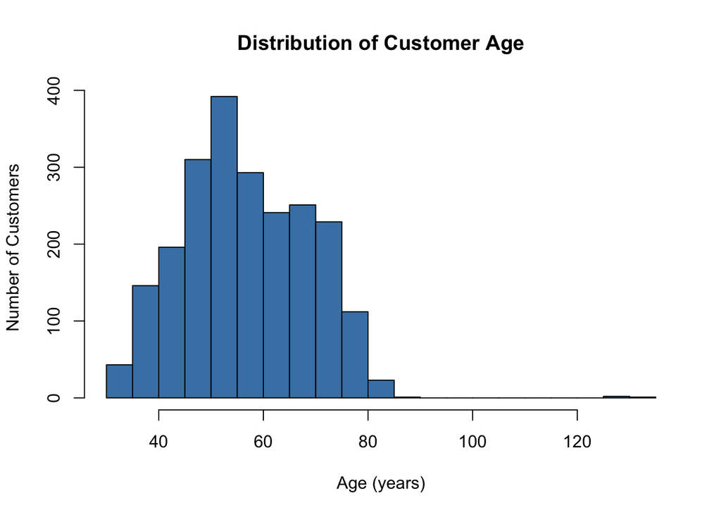

```r
options(scipen = 999)

# Plot 1: Histogram of Age (distribution of a quantitative variable)
hist(marketing$Age,
     main = "Distribution of Customer Age",
     xlab = "Age (years)",
     ylab = "Number of Customers",
     col = "steelblue",
     breaks = 20)
```

*This histogram allows us to confirm a pattern that was previously identified with descriptive statistics. We can see that the majority of the consumers are between 50 and 70 years old. This is a great starting point to start understanding their needs better by building a consumer profile that combines demographic variables, like this, with psychographic variables that present a clear idea of who you’re selling to.*

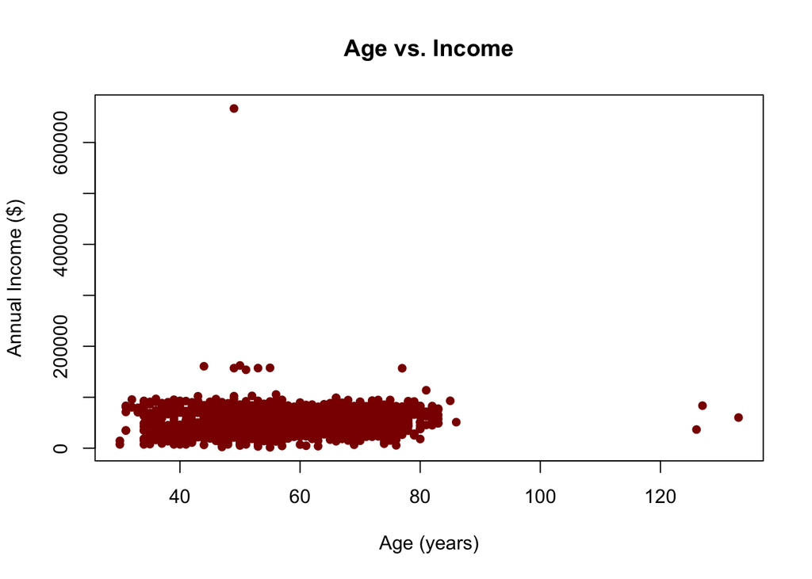

```r
# Plot 2: Scatterplot of Age vs. Income (relationship between two quantitative variables)
plot(marketing$Age, marketing$Income,
     main = "Age vs. Income",
     xlab = "Age (years)",
     ylab = "Annual Income ($)",
     col = "darkred",
     pch = 16)
```

*This scatterplot allows us to identify the average purchasing power of our consumers. In this case, we can determine that almost all of the consumers have a similar annual income despite their age. This information can lead to business decisions like developing a low-cost product that will satisfy a need that these consumers share. And, going back to our age variable created before, this is a great visual way to understand that a bigger income, in this set of consumers, is not significant but most certainly an outlier. As well as confirming the age outliers mentioned before (133)*